# Hypothesis

# Tabular Data Preprocessing

### Museums and Art Galleries

```python
# Get Tourism POI for museum and galleries
# museums
museums_gdf = poi_gdf.loc[poi_gdf['tourism'] == 'museum']
# gallery
galleries_gdf = poi_gdf.loc[poi_gdf['tourism'] == 'gallery']
```

### Airbnb Listings

```
count     5787.000000
mean       339.645758
std       2000.375208
min         39.000000
25%        162.000000
50%        225.000000
75%        315.000000
max      80018.000000
Name: price, dtype: float64
Upper bound for price outliers: €544.50
Dropped outliers: 4830 out of 10316 listings.
count    5486.000000
mean      234.954065
std       102.991455
min        39.000000
25%       160.000000
50%       216.000000
75%       296.000000
max       542.000000
Name: price, dtype: float64
```

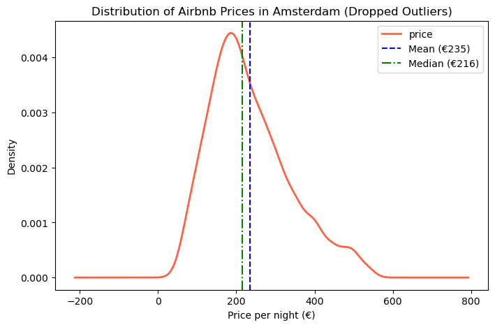

```python
## Stats for airbnb listings and drop outliers
# Drop missing values for price
airbnb_prices = airbnb_gdf.copy()
airbnb_prices["price"] = airbnb_prices["price"].replace("", np.nan)
airbnb_prices = airbnb_prices.dropna(subset=["price"])

# Descriptive stats
print(airbnb_prices["price"].describe())

# Drop outliers via IQR
Q1 = airbnb_prices["price"].quantile(0.25)
Q3 = airbnb_prices["price"].quantile(0.75)
IQR = Q3 - Q1
upper_bound = Q3 + 1.5 * IQR
print(f"Upper bound for price outliers: €{upper_bound:.2f}")
airbnb_prices = airbnb_prices[airbnb_prices["price"] <= upper_bound].copy()
print("Dropped outliers: " + str(len(airbnb_gdf) - len(airbnb_prices)) + " out of " + str(len(airbnb_gdf)) + " listings.")
print(airbnb_prices["price"].describe())

# Plot distribution
plt.figure(figsize=(8, 5))
airbnb_prices["price"].plot(kind="kde", color="tomato", linewidth=2)
mean_price = airbnb_prices["price"].mean()
median_price = airbnb_prices["price"].median()
plt.axvline(mean_price, color="blue", linestyle="--", linewidth=1.5, label=f"Mean (€{mean_price:.0f})")
plt.axvline(median_price, color="green", linestyle="-.", linewidth=1.5, label=f"Median (€{median_price:.0f})")
plt.title("Distribution of Airbnb Prices in Amsterdam (Dropped Outliers)")
plt.xlabel("Price per night (€)")
plt.ylabel("Density")
plt.legend()
plt.show()
```

```
Number of entire home listings with price & date: 4211
Number of private room listings with price & date: 1217
Number of hotel room listings with price & date: 29
Number of shared room listings with price & date: 29
```

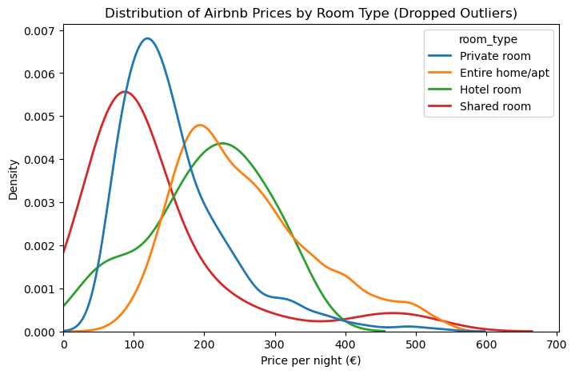

```python
print("Number of entire home listings with price & date: " + str(airbnb_prices.loc[airbnb_prices['room_type']=='Entire home/apt']['price'].count()))
print("Number of private room listings with price & date: " + str(airbnb_prices.loc[airbnb_prices['room_type']=='Private room']['price'].count()))
print("Number of hotel room listings with price & date: " + str(airbnb_prices.loc[airbnb_prices['room_type']=='Hotel room']['price'].count()))
print("Number of shared room listings with price & date: " + str(airbnb_prices.loc[airbnb_prices['room_type']=='Shared room']['price'].count()))

plt.figure(figsize=(8, 5))
sns.kdeplot(data=airbnb_prices,x="price",hue="room_type",common_norm=False,linewidth=2)
plt.title("Distribution of Airbnb Prices by Room Type (Dropped Outliers)")
plt.xlabel("Price per night (€)")
plt.ylabel("Density")
plt.xlim(left=0)
plt.show()
```

```python
airbnb_prices
```

|  | id | name | host_id | host_name | neighbourhood_group | neighbourhood | latitude | longitude | room_type | price | minimum_nights | number_of_reviews | last_review | reviews_per_month | calculated_host_listings_count | availability_365 | number_of_reviews_ltm | license | geometry |
| --- | --- | --- | --- | --- | --- | --- | --- | --- | --- | --- | --- | --- | --- | --- | --- | --- | --- | --- | --- |
| 0 | 27886 | Romantic, stylish B&B houseboat in canal district | 97647 | Flip | None | Centrum-West | 52.387610 | 4.891880 | Private room | 132.0 | 3 | 311 | 2025-09-07 | 1.87 | 1 | 17 | 33 | 0363 974D 4986 7411 88D8 | POINT (121279.758 488976.855) |
| 1 | 28871 | Comfortable double room | 124245 | Edwin | None | Centrum-West | 52.367750 | 4.890920 | Private room | 89.0 | 2 | 732 | 2025-09-07 | 3.99 | 2 | 126 | 93 | 0363 607B EA74 0BD8 2F6F | POINT (121199.272 486767.616) |
| 2 | 29051 | Comfortable single / double room | 124245 | Edwin | None | Centrum-Oost | 52.365840 | 4.891110 | Private room | 61.0 | 2 | 849 | 2025-09-08 | 4.81 | 2 | 95 | 86 | 0363 607B EA74 0BD8 2F6F | POINT (121210.758 486555.015) |
| 5 | 49552 | Multatuli Luxury Guest Suite in top location | 225987 | Joanna & MP | None | Centrum-West | 52.380280 | 4.890890 | Entire home/apt | 322.0 | 3 | 609 | 2025-08-26 | 3.36 | 1 | 223 | 53 | 0363 576A D827 5085 6B83 | POINT (121206.776 488161.756) |
| 6 | 50263 | Central de Lux 2 bedrooms (4p) apt 125 sqm | 230246 | Donald | None | Centrum-Oost | 52.369378 | 4.929579 | Entire home/apt | 457.0 | 2 | 177 | 2025-09-01 | 0.97 | 1 | 354 | 11 | 0363 7F3D 0BAE 28C8 C7D2 | POINT (123833.375 486931.431) |
| ... | ... | ... | ... | ... | ... | ... | ... | ... | ... | ... | ... | ... | ... | ... | ... | ... | ... | ... | ... |
| 10310 | 1503528945274992542 | Pearl of the Cuyp \| Modern Comfort in De Pijp | 717346955 | Dennis | None | De Pijp - Rivierenbuurt | 52.354230 | 4.895250 | Entire home/apt | 423.0 | 2 | 0 | NaT | NaN | 1 | 352 | 0 | 0363 033B 7FC4 5C3A DB9F | POINT (121483.964 485261.332) |
| 10312 | 1504985777531398085 | Bright studio with canal view | 613779 | Silvana | None | Bos en Lommer | 52.377930 | 4.846690 | Entire home/apt | 130.0 | 1 | 0 | NaT | NaN | 4 | 176 | 0 | 0363F7E548AEB29F3BA3 | POINT (118195.359 487921.818) |
| 10313 | 1504998100462399057 | Bright & Spacious Luxury Corner Apartment | 715849738 | Jason | None | Westerpark | 52.373780 | 4.871858 | Entire home/apt | 499.0 | 5 | 0 | NaT | NaN | 1 | 20 | 0 | 0363 5876 BBB2 EF1F 097D | POINT (119905.803 487447.607) |
| 10314 | 1505255613607359391 | Bright and Spacious Ground Floor App. with Garden | 31681093 | Jerom | None | Oud-Noord | 52.386550 | 4.917210 | Entire home/apt | 144.0 | 1 | 0 | NaT | NaN | 1 | 27 | 0 | 0363 3146 D0B7 73A7 E9FA | POINT (123003.368 488847.43) |
| 10315 | 1506287353709120640 | Stylish & cozy apartment in Amsterdam West | 32442604 | Lisa | None | Bos en Lommer | 52.376299 | 4.860642 | Entire home/apt | 152.0 | 2 | 0 | NaT | NaN | 1 | 26 | 0 | 0363 044C 2949 EABC E0B8 | POINT (119144.066 487733.322) |

5486 rows × 19 columns

```python
# Disaggregate airbnb by space type
airbnb_prices_entirespace = airbnb_prices.loc[airbnb_prices['room_type']=='Entire home/apt']
airbnb_prices_privateroom = airbnb_prices.loc[airbnb_prices['room_type']=='Private room']
airbnb_prices_hotelroom = airbnb_prices.loc[airbnb_prices['room_type']=='Hotel room']
airbnb_prices_sharedroom = airbnb_prices.loc[airbnb_prices['room_type']=='Shared room']
```

```python
# Disaggregate airbnbs by dates (high season, low-season)
## Calculate average price per month
# Get month value from date
airbnb_prices_entirespace["last_review"] = pd.to_datetime(airbnb_prices_entirespace["last_review"], errors="coerce")
airbnb_prices_entirespace["review_year"] = airbnb_prices_entirespace["last_review"].dt.year.astype("Int64")
airbnb_prices_entirespace["review_month"] = airbnb_prices_entirespace["last_review"].dt.month.astype("Int64")
airbnb_prices_entirespace["review_month_name"] = airbnb_prices_entirespace["last_review"].dt.month_name()

# Group by month and calculate mean price
avg_price_by_month = (airbnb_prices_entirespace.groupby("review_month")["price"].mean().reset_index().sort_values("review_month"))
print(avg_price_by_month)
# Calculate average price per year
avg_price_by_year = (airbnb_prices_entirespace.groupby("review_year")["price"].mean().reset_index().sort_values("review_year"))
print(avg_price_by_year)

avg_price_by_month["month_name"] = avg_price_by_month["review_month"].apply(lambda x: calendar.month_name[int(x)] if pd.notna(x) else None)
```

```
    review_month       price
0              1  242.390244
1              2  219.630435
2              3  210.909091
3              4  265.990536
4              5  248.368957
5              6  259.353808
6              7  276.509804
7              8  257.535805
8              9  250.720617
9             10  273.420000
10            11  236.142857
11            12  227.875000
   review_year       price
0         2017  218.833333
1         2018  230.142857
2         2019  262.529412
3         2020  248.000000
4         2021  184.555556
5         2022  279.829268
6         2023  267.417266
7         2024  256.098876
8         2025  257.691436
```

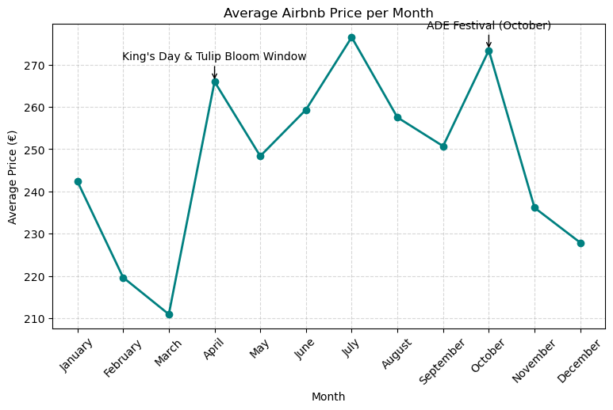

```python
# Plot prices by month
plt.figure(figsize=(9, 5))
plt.plot(
    avg_price_by_month["review_month"],
    avg_price_by_month["price"],
    marker="o",
    color="teal",
    linewidth=2
)

# annotate with note about King's Day & Tulip Bloom
apr_mask = avg_price_by_month["review_month"] == 4
x_apr = avg_price_by_month.loc[apr_mask, "review_month"].iloc[0]
y_apr = avg_price_by_month.loc[apr_mask, "price"].iloc[0]
plt.annotate("King's Day & Tulip Bloom Window",xy=(x_apr, y_apr),xytext=(0, 20),textcoords="offset points",arrowprops=dict(arrowstyle="->", linewidth=1),ha="center")
# annotate with note about October ADE
oct_mask = avg_price_by_month["review_month"] == 10
x_oct = avg_price_by_month.loc[oct_mask, "review_month"].iloc[0]
y_oct = avg_price_by_month.loc[oct_mask, "price"].iloc[0]
plt.annotate("ADE Festival (October)",xy=(x_oct, y_oct),xytext=(0, 20),textcoords="offset points",arrowprops=dict(arrowstyle="->", linewidth=1),ha="center")

plt.title("Average Airbnb Price per Month")
plt.xlabel("Month")
plt.ylabel("Average Price (€)")
plt.xticks(
    avg_price_by_month["review_month"],
    avg_price_by_month["month_name"],
    rotation=45
)
plt.grid(True, linestyle="--", alpha=0.5)
plt.show()
```

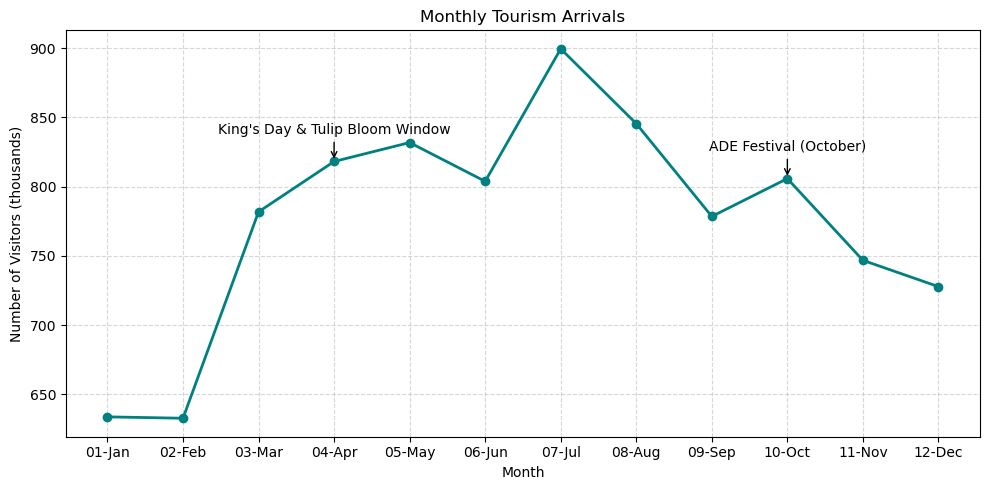

```python
## Look at Amsterdam tourism arrivals to determine high season vs low season
visitorstats_df = visitorstats_df.drop(columns=["Unnamed: 12"], errors="ignore")
visitorstats_long = visitorstats_df.melt(var_name="Month", value_name="Visitors")
visitorstats_long["Visitors"] = pd.to_numeric(visitorstats_long["Visitors"], errors="coerce")
month_order = ["01-Jan", "02-Feb", "03-Mar", "04-Apr", "05-May", "06-Jun",
               "07-Jul", "08-Aug", "09-Sep", "10-Oct", "11-Nov", "12-Dec"]
visitorstats_long["Month"] = pd.Categorical(visitorstats_long["Month"], categories=month_order, ordered=True)
visitorstats_long = visitorstats_long.sort_values("Month")

plt.figure(figsize=(10, 5))
plt.plot(
    visitorstats_long["Month"].astype(str),   # force string labels
    visitorstats_long["Visitors"],
    marker="o", color="teal", linewidth=2
)

# annotate with note about King's Day & Tulip Bloom
apr_mask = visitorstats_long["Month"] == "04-Apr"
x_apr = visitorstats_long.loc[apr_mask, "Month"].iloc[0]
y_apr = visitorstats_long.loc[apr_mask, "Visitors"].iloc[0]
plt.annotate("King's Day & Tulip Bloom Window",xy=(x_apr, y_apr),xytext=(0, 20),textcoords="offset points",arrowprops=dict(arrowstyle="->", linewidth=1),ha="center")
# annotate with note about October ADE
oct_mask = visitorstats_long["Month"] == "10-Oct"
x_oct = visitorstats_long.loc[oct_mask, "Month"].astype(str).iloc[0]
y_oct = visitorstats_long.loc[oct_mask, "Visitors"].iloc[0]
plt.annotate("ADE Festival (October)",xy=(x_oct, y_oct),xytext=(0, 20),textcoords="offset points",arrowprops=dict(arrowstyle="->", linewidth=1),ha="center")

plt.title("Monthly Tourism Arrivals")
plt.xlabel("Month")
plt.ylabel("Number of Visitors (thousands)")
plt.grid(True, linestyle="--", alpha=0.5)
plt.tight_layout()
plt.show()
```

```python
# Define high season months and low season months based on 6 months with highest/lowest tourist arrivals
high_season = ['April', 'May', 'June', 'July', 'August', 'October']
low_season = ['January', 'February', 'March', 'September', 'November', 'December']
july = ['July']
ade = ['October']
airbnb_prices_entirespace_highseason = airbnb_prices_entirespace[airbnb_prices_entirespace['review_month_name'].isin(high_season)].copy()
airbnb_prices_entirespace_lowseason = airbnb_prices_entirespace[airbnb_prices_entirespace['review_month_name'].isin(low_season)].copy()
airbnb_prices_entirespace_july = airbnb_prices_entirespace[airbnb_prices_entirespace['review_month_name'].isin(july)].copy()
airbnb_prices_entirespace_ade = airbnb_prices_entirespace[airbnb_prices_entirespace['review_month_name'].isin(ade)].copy()
```

```
Number of entire home listings in high season: 2914
Number of entire home listings in low season: 761
```

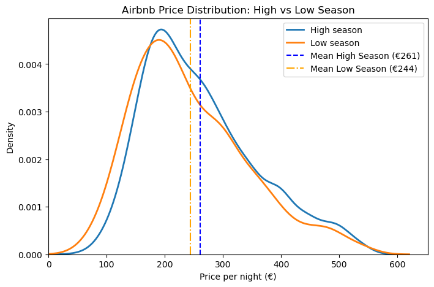

```python
print("Number of entire home listings in high season: " + str(airbnb_prices_entirespace_highseason['price'].count()))
print("Number of entire home listings in low season: " + str(airbnb_prices_entirespace_lowseason['price'].count()))

plt.figure(figsize=(8, 5))
sns.kdeplot(
    data=airbnb_prices_entirespace_highseason,
    x="price",
    linewidth=2,
    label="High season"
)

sns.kdeplot(
    data=airbnb_prices_entirespace_lowseason,
    x="price",
    linewidth=2,
    label="Low season"
)

high_mean_price = airbnb_prices_entirespace_highseason["price"].mean()
low_mean_price = airbnb_prices_entirespace_lowseason["price"].mean()
plt.axvline(high_mean_price, color="blue", linestyle="--", linewidth=1.5, label=f"Mean High Season (€{high_mean_price:.0f})")
plt.axvline(low_mean_price, color="orange", linestyle="-.", linewidth=1.5, label=f"Mean Low Season (€{low_mean_price:.0f})")
plt.title("Airbnb Price Distribution: High vs Low Season")
plt.xlabel("Price per night (€)")
plt.ylabel("Density")
plt.xlim(left=0)
plt.legend()
plt.show()
```

# Spatial Data Preprocessing

We want to perform a spatial join into our geodataframe containing the multipologyoin geometries of the census neighbrhoods, so that we can use this file in choropleth mapping and autocorrelation analysis.

```python
neighborhood_stats = buurten_gdf.copy()
```

Perform a spatial join to census polygons using point geometries from processed geodataframes.

1. Add count_airbnbs to each polygon by counting the number of points (from "airbnb_gdf") located in each polygon.
2. Add avg_price_airbnb to each polygon by averaging the 'price' of all points (from "airbnb_prices" gdf) located in each polygon.
3. Add avg_price_airbnb_entirespace to each polygon by averaging the 'price' of all points (from "airbnb_prices_entirespace" gdf) located in each polygon.
4. Add avg_price_airbnb_entirespace_highseason to each polygon by averaging the 'price' of all points (from "airbnb_prices_entirespace_highseason" gdf) located in each polygon.
5. Add avg_price_airbnb_entirespace_lowseason to each polygon by averaging the 'price' of all points (from "airbnb_prices_entirespace_lowseason" gdf) located in each polygon.
6. Add count_pois to each polygon by counting the number of points (from "poi_gdf") located in each polygon.
7. Add count_museums to each polygon by counting the number of points (from "museums_gdf") located in each polygon.
8. Add count_galleries to each polygon by counting the number of points (from "galleries_gdf") located in each polygon.
9. Add count_monuments to each polygon by counting the number of points (from "monuments_gdf") located in each polygon.

```python
# define function to get point count per polygon and average price per polygon
def add_point_count(polygons, points, new_col, predicate="intersects"):
    """
    Count how many points fall in each neighborhood polygon.
    """
    # Spatial join: each point gets the index of the polygon it falls in
    joined = gpd.sjoin(
        points[["geometry"]],
        polygons[["geometry"]],
        how="left",
        predicate=predicate,
    )

    # Drop points that did not match any polygon
    joined = joined.dropna(subset=["index_right"])

    # Count points per neighborhood (index_right is the polygon index)
    counts = (
        joined.groupby("index_right")
        .size()
        .rename(new_col)
    )

    # Attach back to neighborhoods by index
    polygons[new_col] = counts
    # Neighborhoods with no points get 0 instead of NaN
    polygons[new_col] = polygons[new_col].fillna(0).astype(int)

    return polygons


def add_point_mean(polygons, points, value_col, new_col, predicate="intersects"):
    """
    Compute the mean of `value_col` for points in each neighborhood polygon.
    """
    joined = gpd.sjoin(
        points[[value_col, "geometry"]],
        polygons[["geometry"]],
        how="left",
        predicate=predicate,
    )

    joined = joined.dropna(subset=["index_right"])

    means = (
        joined.groupby("index_right")[value_col]
        .mean()
        .rename(new_col)
    )

    polygons[new_col] = means  # polygons with no points stay NaN (no data)

    return polygons
```

```python
# Run both functions to get counts and averages per polygon

# Total Airbnb count per neighborhood
neighborhood_stats = add_point_count(
    neighborhood_stats,
    airbnb_gdf,
    new_col="count_airbnbs"
)

# Average airbnb price per night (all)
neighborhood_stats = add_point_mean(
    neighborhood_stats,
    airbnb_prices,
    value_col="price",
    new_col="avg_price_airbnb"
)

# Average airbnb price per night (entire space)
neighborhood_stats = add_point_mean(
    neighborhood_stats,
    airbnb_prices_entirespace,
    value_col="price",
    new_col="avg_price_airbnb_entirespace"
)

# Average airbnb price per night (entire space - high season)
neighborhood_stats = add_point_mean(
    neighborhood_stats,
    airbnb_prices_entirespace_highseason,
    value_col="price",
    new_col="avg_price_airbnb_entirespace_highseason"
)

# Average airbnb price per night (entire space - low season)
neighborhood_stats = add_point_mean(
    neighborhood_stats,
    airbnb_prices_entirespace_lowseason,
    value_col="price",
    new_col="avg_price_airbnb_entirespace_lowseason"
)

# Average airbnb price per night (entire space - July)
neighborhood_stats = add_point_mean(
    neighborhood_stats,
    airbnb_prices_entirespace_july,
    value_col="price",
    new_col="avg_price_airbnb_entirespace_july"
)

# Average airbnb price per night (entire space - Amsterdam Dance Event)
neighborhood_stats = add_point_mean(
    neighborhood_stats,
    airbnb_prices_entirespace_ade,
    value_col="price",
    new_col="avg_price_airbnb_entirespace_ade"
)

# OSM Tourism POI count per neighborhood
neighborhood_stats = add_point_count(
    neighborhood_stats,
    poi_gdf,
    new_col="count_pois"
)

# OSM Museum count per neighborhood
neighborhood_stats = add_point_count(
    neighborhood_stats,
    museums_gdf,
    new_col="count_museums"
)

# OSM Gallery count per neighborhood
neighborhood_stats = add_point_count(
    neighborhood_stats,
    galleries_gdf,
    new_col="count_galleries"
)

# Rijkmonumenten count per neighborhood
neighborhood_stats = add_point_count(
    neighborhood_stats,
    monuments_gdf,
    new_col="count_monuments"
)
```

# Export

```python
# write files to data/final_processed_data/
folder_path = "data/final_processed_data/"
output_gdfs = {
    "neighborhood_stats": neighborhood_stats,
    "airbnb_listings": airbnb_gdf,
    "airbnb_prices": airbnb_prices,
    "airbnb_prices_entirespace": airbnb_prices_entirespace,
    "airbnb_prices_entirespace_highseason": airbnb_prices_entirespace_highseason,
    "airbnb_prices_entirespace_lowseason": airbnb_prices_entirespace_lowseason,
    "tourism_pois": poi_gdf,
    "museum_pois": museums_gdf,
    "gallery_pois": galleries_gdf,
    "monument_pois": monuments_gdf,
    "neighborhood_polygons": buurten_gdf,
}

for name, gdf in output_gdfs.items():
    out_path = f"{folder_path}{name}.gpkg"
    gdf.to_file(out_path, driver="GPKG")
    print(f"Saved {name} → {out_path}")
```

```
Saved neighborhood_stats → data/final_processed_data/neighborhood_stats.gpkg
Saved airbnb_listings → data/final_processed_data/airbnb_listings.gpkg
Saved airbnb_prices → data/final_processed_data/airbnb_prices.gpkg
Saved airbnb_prices_entirespace → data/final_processed_data/airbnb_prices_entirespace.gpkg
Saved airbnb_prices_entirespace_highseason → data/final_processed_data/airbnb_prices_entirespace_highseason.gpkg
Saved airbnb_prices_entirespace_lowseason → data/final_processed_data/airbnb_prices_entirespace_lowseason.gpkg
Saved tourism_pois → data/final_processed_data/tourism_pois.gpkg
Saved museum_pois → data/final_processed_data/museum_pois.gpkg
Saved gallery_pois → data/final_processed_data/gallery_pois.gpkg
Saved monument_pois → data/final_processed_data/monument_pois.gpkg
Saved neighborhood_polygons → data/final_processed_data/neighborhood_polygons.gpkg
```